# Biostat 203B Homework 5

Due Mar 22 @ 11:59PM

Author

Zijie Chen 305975150

## Predicting ICU duration

Using the ICU cohort `mimiciv_icu_cohort.rds` you built in Homework 4, develop at least three machine learning approaches (logistic regression with enet regularization, random forest, boosting, SVM, MLP, etc) plus a model stacking approach for predicting whether a patient’s ICU stay will be longer than 2 days. You should use the `los_long` variable as the outcome. You algorithms can use patient demographic information (gender, age at ICU `intime`, marital status, race), ICU admission information (first care unit), the last lab measurements before the ICU stay, and first vital measurements during ICU stay as features. You are welcome to use any feature engineering techniques you think are appropriate; but make sure to not use features that are not available at an ICU stay’s `intime`. For instance, `last_careunit` cannot be used in your algorithms.

#1. Data preprocessing and feature engineering.

### Library

```r
library(tidyverse)
library(tidymodels)
library(ggplot2)
library(corrplot)
library(ggthemes)
library(naniar)
library(kableExtra)
library(ISLR)
library(ISLR2)
library(glmnet)
library(themis)
library(discrim)
library(corrplot)
library(modeldata)
library(janitor)
library(xgboost)
library(ranger)
library(vip)
library(keras)
library(corrplot)
library(gtsummary)
library(tensorflow)
library(stacks)
tidymodels_prefer()
```

### EDA

```r
mimic_icu_cohort <- read_rds("mimic_icu_cohort.rds")
head(mimic_icu_cohort)
```

```
# A tibble: 6 × 42
  subject_id  hadm_id  stay_id first_careunit  last_careunit intime
       <int>    <int>    <int> <fct>           <fct>         <dttm>
1   10000032 29079034 39553978 Medical Intens… Medical Inte… 2180-07-23 14:00:00
2   10000980 26913865 39765666 Medical Intens… Medical Inte… 2189-06-27 08:42:00
3   10001217 24597018 37067082 Surgical Inten… Surgical Int… 2157-11-20 19:18:02
4   10001217 27703517 34592300 Surgical Inten… Surgical Int… 2157-12-19 15:42:24
5   10001725 25563031 31205490 Medical/Surgic… Medical/Surg… 2110-04-11 15:52:22
6   10001884 26184834 37510196 Medical Intens… Medical Inte… 2131-01-11 04:20:05
# ℹ 36 more variables: outtime <dttm>, los <dbl>, admittime <dttm>,
#   dischtime <dttm>, deathtime <dttm>, admission_type <fct>,
#   admit_provider_id <chr>, admission_location <fct>,
#   discharge_location <fct>, insurance <chr>, language <chr>,
#   marital_status <chr>, race <fct>, edregtime <dttm>, edouttime <dttm>,
#   hospital_expire_flag <int>, gender <chr>, anchor_age <int>,
#   anchor_year <int>, anchor_year_group <chr>, dod <date>, age_intime <int>, …
```

```r
dim(mimic_icu_cohort)
```

```
[1] 73181    42
```

```r
colnames(mimic_icu_cohort)
```

```
 [1] "subject_id"
 [2] "hadm_id"
 [3] "stay_id"
 [4] "first_careunit"
 [5] "last_careunit"
 [6] "intime"
 [7] "outtime"
 [8] "los"
 [9] "admittime"
[10] "dischtime"
[11] "deathtime"
[12] "admission_type"
[13] "admit_provider_id"
[14] "admission_location"
[15] "discharge_location"
```

[output cut: 27 more lines]

```r
summary_table <- mimic_icu_cohort %>%
  select(first_careunit, los, admission_type,
         admission_location, discharge_location, insurance, language,
         marital_status, race, hospital_expire_flag, gender,
         dod, Sodium, Chloride, Creatinine, Potassium,
         Glucose, Hematocrit, `White Blood Cells`, Bicarbonate,
         `Temperature Fahrenheit`, `Non Invasive Blood Pressure diastolic`,
         `Respiratory Rate`, `Non Invasive Blood Pressure systolic`,
         `Heart Rate`, age_intime, los_long) |>
  tbl_summary(by = los_long)
summary_table
```

| **Characteristic** | **FALSE**, N = 38,050<sup>1</sup> | **TRUE**, N = 35,131<sup>1</sup> |
| --- | --- | --- |
| first_careunit |  |  |
| Cardiac Vascular Intensive Care Unit (CVICU) | 5,827 (15%) | 5,755 (16%) |
| Medical Intensive Care Unit (MICU) | 8,782 (23%) | 7,116 (20%) |
| Medical/Surgical Intensive Care Unit (MICU/SICU) | 7,147 (19%) | 5,586 (16%) |
| Surgical Intensive Care Unit (SICU) | 5,654 (15%) | 5,507 (16%) |
| Other | 10,640 (28%) | 11,167 (32%) |
| los | 1.1 (0.8, 1.5) | 3.8 (2.7, 6.6) |
| admission_type |  |  |
| EW EMER. | 20,735 (54%) | 17,937 (51%) |
| OBSERVATION ADMIT | 4,329 (11%) | 4,645 (13%) |
| SURGICAL SAME DAY ADMISSION | 4,340 (11%) | 3,033 (8.6%) |
| URGENT | 5,494 (14%) | 6,959 (20%) |
| Other | 3,152 (8.3%) | 2,557 (7.3%) |
| admission_location |  |  |
| EMERGENCY ROOM | 19,602 (52%) | 16,279 (46%) |
| PHYSICIAN REFERRAL | 8,986 (24%) | 7,412 (21%) |
| TRANSFER FROM HOSPITAL | 6,839 (18%) | 8,959 (26%) |
| WALK-IN/SELF REFERRAL | 876 (2.3%) | 791 (2.3%) |
| Other | 1,747 (4.6%) | 1,690 (4.8%) |
| discharge_location |  |  |
| DIED | 3,298 (8.8%) | 5,006 (14%) |
| HOME | 12,192 (33%) | 5,255 (15%) |
| HOME HEALTH CARE | 10,347 (28%) | 7,762 (22%) |
| SKILLED NURSING FACILITY | 6,239 (17%) | 7,158 (20%) |
| Other | 5,402 (14%) | 9,885 (28%) |
| Unknown | 572 | 65 |
| insurance |  |  |
| Medicaid | 3,060 (8.0%) | 2,468 (7.0%) |
| Medicare | 16,489 (43%) | 16,602 (47%) |
| Other | 18,501 (49%) | 16,061 (46%) |
| language |  |  |
| ? | 3,692 (9.7%) | 3,751 (11%) |
| ENGLISH | 34,358 (90%) | 31,380 (89%) |
| marital_status |  |  |
| DIVORCED | 2,843 (8.0%) | 2,561 (7.9%) |
| MARRIED | 16,984 (48%) | 15,784 (49%) |
| SINGLE | 11,175 (31%) | 9,683 (30%) |
| WIDOWED | 4,699 (13%) | 4,339 (13%) |
| Unknown | 2,349 | 2,764 |
| race |  |  |
| Other | 5,160 (14%) | 5,596 (16%) |
| ASIAN | 1,148 (3.0%) | 1,007 (2.9%) |
| BLACK | 4,311 (11%) | 3,649 (10%) |
| HISPANIC | 1,492 (3.9%) | 1,249 (3.6%) |
| WHITE | 25,939 (68%) | 23,630 (67%) |
| hospital_expire_flag | 3,357 (8.8%) | 4,972 (14%) |
| gender |  |  |
| F | 17,014 (45%) | 15,349 (44%) |
| M | 21,036 (55%) | 19,782 (56%) |
| dod | 2110-02-08 to 2210-12-04 | 2110-01-25 to 2211-01-17 |
| Unknown | 24,904 | 20,003 |
| Sodium | 139.0 (136.0, 141.0) | 138.0 (135.0, 141.0) |
| Unknown | 4,174 | 4,698 |
| Chloride | 102 (98, 105) | 102 (98, 105) |
| Unknown | 4,175 | 4,708 |
| Creatinine | 1.00 (0.80, 1.40) | 1.00 (0.80, 1.60) |
| Unknown | 2,599 | 3,171 |
| Potassium | 4.20 (3.80, 4.60) | 4.20 (3.80, 4.70) |
| Unknown | 4,189 | 4,712 |
| Glucose | 118 (98, 153) | 122 (100, 159) |
| Unknown | 4,282 | 4,817 |
| Hematocrit | 36 (30, 40) | 35 (29, 40) |
| Unknown | 2,236 | 2,781 |
| White Blood Cells | 9.0 (6.6, 12.6) | 9.7 (7.0, 13.8) |
| Unknown | 2,272 | 2,822 |
| Bicarbonate | 25.0 (22.0, 27.0) | 24.0 (21.0, 27.0) |
| Unknown | 4,270 | 4,780 |
| Temperature Fahrenheit | 98.10 (97.60, 98.60) | 98.20 (97.60, 98.80) |
| Unknown | 1,079 | 170 |
| Non Invasive Blood Pressure diastolic | 68 (58, 80) | 66 (56, 79) |
| Unknown | 709 | 244 |
| Respiratory Rate | 18.0 (15.0, 22.0) | 19.0 (15.0, 23.0) |
| Unknown | 81 | 10 |
| Non Invasive Blood Pressure systolic | 123 (108, 140) | 120 (104, 138) |
| Unknown | 709 | 241 |
| Heart Rate | 85 (74, 99) | 88 (76, 103) |
| Unknown | 17 | 1 |
| age_intime | 65 (53, 77) | 67 (56, 78) |

<sup>1</sup> n (%); Median (IQR); Range

```r
colSums(is.na(mimic_icu_cohort))
```

```
                           subject_id                               hadm_id
                                    0                                     0
                              stay_id                        first_careunit
                                    0                                     0
                        last_careunit                                intime
                                    0                                     0
                              outtime                                   los
                                    0                                     0
                            admittime                             dischtime
                                    0                                     0
                            deathtime                        admission_type
                                64860                                     0
                    admit_provider_id                    admission_location
                                    2                                     0
                   discharge_location                             insurance
                                  637                                     0
                             language                        marital_status
                                    0                                  5113
                                 race                             edregtime
                                    0                                 24898
                            edouttime                  hospital_expire_flag
                                24898                                     0
                               gender                            anchor_age
                                    0                                     0
                          anchor_year                     anchor_year_group
                                    0                                     0
                                  dod                            age_intime
                                44907                                     0
                           Creatinine                     White Blood Cells
                                 5770                                  5094
                              Glucose                            Hematocrit
                                 9099                                  5017
                          Bicarbonate                             Potassium
                                 9050                                  8901
                             Chloride                                Sodium
                                 8883                                  8872
                     Respiratory Rate                            Heart Rate
                                   91                                    18
 Non Invasive Blood Pressure systolic Non Invasive Blood Pressure diastolic
                                  950                                   953
               Temperature Fahrenheit                              los_long
                                 1249                                     0
```

### Feature Engineering

```r
#unique(mimic_icu_cohort$admit_provider_id)
```

```r
mimiciv_icu_cohort <- mimic_icu_cohort %>%
  select(-c(last_careunit,dod,los,deathtime,
            edregtime,edouttime, discharge_location,
            outtime, dischtime,
            admit_provider_id, anchor_year_group))
```

Factor the factor variables

```r
mimiciv_icu_cohort <- mimiciv_icu_cohort %>%
  mutate(los_long = factor(los_long),
         insurance = factor(insurance),
         language = factor(language),
         marital_status = factor(marital_status),
         hospital_expire_flag = factor(hospital_expire_flag),
         gender = factor(gender)
  )
```

To replace spaces with underscores in all column names

```r
names(mimiciv_icu_cohort) <- gsub(" ", "_", names(mimiciv_icu_cohort))
```

We also have to convert intime and admittime to a data type that model can process, I have decided to convert them to a three levels factor with the levels being morning, afternoon and night.

```r
convert_time_to_factor <- function(time_column) {
  sapply(time_column, function(time) {
    hour <- as.integer(format(time, "%H"))
    if (hour >= 5 && hour <= 11) {
      return("Morning")
    } else if (hour >= 12 && hour <= 17) {
      return("Afternoon")
    } else {
      return("Night")
    }
  }) -> time_factors

  return(factor(time_factors, levels = c("Morning", "Afternoon", "Night")))
}

mimiciv_icu_cohort$intime <- convert_time_to_factor(mimiciv_icu_cohort$intime)
mimiciv_icu_cohort$admittime <- convert_time_to_factor(mimiciv_icu_cohort$admittime)
```

#2. Partition data into 50% training set and 50% test set. Stratify partitioning according to `los_long`. For grading purpose, sort the data by `subject_id`, `hadm_id`, and `stay_id` and use the seed `203` for the initial data split. Below is the sample code.

```r
set.seed(203)

# sort
mimiciv_icu_cohort <- mimiciv_icu_cohort %>%
  arrange(subject_id, hadm_id, stay_id)

# Drop the id columns, since they are not useful for modeling
mimiciv_icu_cohort <- mimiciv_icu_cohort %>%
  select(-c(subject_id, hadm_id, stay_id))

data_split <- initial_split(
  mimiciv_icu_cohort,
  # stratify by los_long
  strata = "los_long",
  prop = 0.5
  )

Mimic_other <- training(data_split)
dim(Mimic_other)
```

```
[1] 36590    28
```

```r
Mimic_test <- testing(data_split)
dim(Mimic_test)
```

```
[1] 36591    28
```

```r
colSums(is.na(mimiciv_icu_cohort))
```

```
                       first_careunit                                intime
                                    0                                     0
                            admittime                        admission_type
                                    0                                     0
                   admission_location                             insurance
                                    0                                     0
                             language                        marital_status
                                    0                                  5113
                                 race                  hospital_expire_flag
                                    0                                     0
                               gender                            anchor_age
                                    0                                     0
                          anchor_year                            age_intime
                                    0                                     0
                           Creatinine                     White_Blood_Cells
                                 5770                                  5094
                              Glucose                            Hematocrit
                                 9099                                  5017
                          Bicarbonate                             Potassium
                                 9050                                  8901
                             Chloride                                Sodium
                                 8883                                  8872
                     Respiratory_Rate                            Heart_Rate
                                   91                                    18
 Non_Invasive_Blood_Pressure_systolic Non_Invasive_Blood_Pressure_diastolic
                                  950                                   953
               Temperature_Fahrenheit                              los_long
                                 1249                                     0
```

#3. Train and tune the models using the training set.

### Recipe

There are missing values, since missing values are not too much, I would use mean to impute the missing values for the numeric variables and knn method for the categorical variables. As we know, using mean to impute missing values will affect the sample variance. But it also limits the leverage of missing data.

```r
mimic_recipe <-
  recipe(
    los_long ~ .,
    data = Mimic_other
  ) %>%
  step_impute_mean(all_numeric_predictors()) %>%
  step_impute_knn(all_nominal_predictors()) %>%
  step_dummy(all_nominal_predictors()) %>%
  step_zv(all_numeric_predictors()) %>%
  step_normalize(all_numeric_predictors()) %>%
  prep(training = Mimic_other, retain = TRUE)
mimic_recipe %>% bake(Mimic_other)
```

```
# A tibble: 36,590 × 45
   anchor_age anchor_year age_intime Creatinine White_Blood_Cells   Glucose
        <dbl>       <dbl>      <dbl>      <dbl>             <dbl>     <dbl>
 1     0.580       1.44       0.670    4.88e- 1         -6.30e- 1 -6.46e- 1
 2     0.996      -1.01       1.09    -6.05e- 2         -1.36e- 1 -1.25e- 1
 3    -0.905       1.74      -0.695   -5.48e- 1         -8.93e- 1 -3.85e- 1
 4     0.342       0.808      0.492   -1.21e- 1         -1.19e+ 0 -4.68e- 1
 5     0.0455      0.0878    -0.0422   4.90e-14         -3.12e- 1  1.30e-13
 6    -1.80        0.893     -1.88     4.90e-14          1.50e-14  1.30e-13
 7     0.105      -0.505      0.0765  -1.82e- 1         -5.20e- 1 -4.09e- 1
 8     0.758      -1.01       0.788   -3.04e- 1         -3.88e- 1 -3.26e- 1
 9    -0.667      -1.73      -0.754    4.90e-14          1.50e-14  1.30e-13
10     1.47        1.02       1.38    -3.65e- 1         -3.01e- 1 -3.97e- 1
# ℹ 36,580 more rows
# ℹ 39 more variables: Hematocrit <dbl>, Bicarbonate <dbl>, Potassium <dbl>,
#   Chloride <dbl>, Sodium <dbl>, Respiratory_Rate <dbl>, Heart_Rate <dbl>,
#   Non_Invasive_Blood_Pressure_systolic <dbl>,
#   Non_Invasive_Blood_Pressure_diastolic <dbl>, Temperature_Fahrenheit <dbl>,
#   los_long <fct>, first_careunit_Medical.Intensive.Care.Unit..MICU. <dbl>,
#   first_careunit_Medical.Surgical.Intensive.Care.Unit..MICU.SICU. <dbl>, …
```

### Model

```r
logit_mod <-
  logistic_reg(
    penalty = tune(),
    mixture = tune()
  ) %>%
  set_engine("glmnet", standardize = FALSE) %>%
  print()
```

```
Logistic Regression Model Specification (classification)

Main Arguments:
  penalty = tune()
  mixture = tune()

Engine-Specific Arguments:
  standardize = FALSE

Computational engine: glmnet
```

```r
rf_mod <-
  rand_forest(
    mode = "classification",
    mtry = tune(),
    trees = tune()
  ) %>%
  set_engine("ranger", importance = "impurity") %>%
  print()
```

```
Random Forest Model Specification (classification)

Main Arguments:
  mtry = tune()
  trees = tune()

Engine-Specific Arguments:
  importance = impurity

Computational engine: ranger
```

```r
mlp_mod <-
  mlp(
    mode = "classification",
    hidden_units = tune(),
    dropout = tune(),
    epochs = 5,
  ) %>%
  set_engine("keras", verbose = 0) %>%
  print()
```

```
Single Layer Neural Network Model Specification (classification)

Main Arguments:
  hidden_units = tune()
  dropout = tune()
  epochs = 5

Engine-Specific Arguments:
  verbose = 0

Computational engine: keras
```

```r
gb_mod <-
  boost_tree(
    mode = "classification",
    trees = 200,
    tree_depth = tune(),
    learn_rate = tune()
  ) %>%
  set_engine("xgboost") %>%
  print()
```

```
Boosted Tree Model Specification (classification)

Main Arguments:
  trees = 200
  tree_depth = tune()
  learn_rate = tune()

Computational engine: xgboost
```

### Workflow

```r
logit_wf <- workflow() %>%
  add_recipe(mimic_recipe) %>%
  add_model(logit_mod) %>%
  print()
```

```
══ Workflow ════════════════════════════════════════════════════════════════════
Preprocessor: Recipe
Model: logistic_reg()

── Preprocessor ────────────────────────────────────────────────────────────────
5 Recipe Steps

• step_impute_mean()
• step_impute_knn()
• step_dummy()
• step_zv()
• step_normalize()

── Model ───────────────────────────────────────────────────────────────────────
Logistic Regression Model Specification (classification)

Main Arguments:
  penalty = tune()
  mixture = tune()

Engine-Specific Arguments:
  standardize = FALSE

Computational engine: glmnet
```

```r
rf_wf <- workflow() %>%
  add_recipe(mimic_recipe) %>%
  add_model(rf_mod) %>%
  print()
```

```
══ Workflow ════════════════════════════════════════════════════════════════════
Preprocessor: Recipe
Model: rand_forest()

── Preprocessor ────────────────────────────────────────────────────────────────
5 Recipe Steps

• step_impute_mean()
• step_impute_knn()
• step_dummy()
• step_zv()
• step_normalize()

── Model ───────────────────────────────────────────────────────────────────────
Random Forest Model Specification (classification)

Main Arguments:
  mtry = tune()
  trees = tune()

Engine-Specific Arguments:
  importance = impurity

Computational engine: ranger
```

```r
mlp_wf <- workflow() %>%
  add_recipe(mimic_recipe) %>%
  add_model(mlp_mod) %>%
  print()
```

```
══ Workflow ════════════════════════════════════════════════════════════════════
Preprocessor: Recipe
Model: mlp()

── Preprocessor ────────────────────────────────────────────────────────────────
5 Recipe Steps

• step_impute_mean()
• step_impute_knn()
• step_dummy()
• step_zv()
• step_normalize()

── Model ───────────────────────────────────────────────────────────────────────
Single Layer Neural Network Model Specification (classification)

Main Arguments:
  hidden_units = tune()
  dropout = tune()
  epochs = 5

Engine-Specific Arguments:
  verbose = 0

Computational engine: keras
```

```r
gb_wf <- workflow() %>%
  add_recipe(mimic_recipe) %>%
  add_model(gb_mod) %>%
  print()
```

```
══ Workflow ════════════════════════════════════════════════════════════════════
Preprocessor: Recipe
Model: boost_tree()

── Preprocessor ────────────────────────────────────────────────────────────────
5 Recipe Steps

• step_impute_mean()
• step_impute_knn()
• step_dummy()
• step_zv()
• step_normalize()

── Model ───────────────────────────────────────────────────────────────────────
Boosted Tree Model Specification (classification)

Main Arguments:
  trees = 200
  tree_depth = tune()
  learn_rate = tune()

Computational engine: xgboost
```

### Tuning grid

```r
logit_param_grid <- grid_regular(
  penalty(range = c(-6, 3)),
  mixture(),
  levels = c(100, 5)
  )

rf_param_grid <- grid_regular(
  trees(range = c(100L, 400L)),
  mtry(range = c(1L, 6L)),
  levels = c(5, 5)
  )

mlp_param_grid <- grid_regular(
  hidden_units(range = c(1, 20)),
  dropout(range = c(0, 0.6)),
  levels = 3
  )

gb_param_grid <- grid_regular(
  tree_depth(range = c(1L, 6L)),
  learn_rate(range = c(-5, 2), trans = log10_trans()),
  levels = c(3, 10)
  )
```

### Cross_validation

```r
set.seed(203)
folds <- vfold_cv(Mimic_other, v = 5)
```

#### logistic regression with enet regularization

```r
logit_fit <-
    tune_grid(
    object = logit_wf,
    resamples = folds,
    grid = logit_param_grid,
    control = control_stack_grid()
  )
```

```
ℹ The workflow being saved contains a recipe, which is 18.29 Mb in ℹ memory. If
this was not intentional, please set the control setting ℹ `save_workflow =
FALSE`.
```

```
# A tibble: 1,000 × 8
      penalty mixture .metric  .estimator  mean     n std_err
        <dbl>   <dbl> <chr>    <chr>      <dbl> <int>   <dbl>
 1 0.000001         0 accuracy binary     0.588     5 0.00220
 2 0.000001         0 roc_auc  binary     0.623     5 0.00246
 3 0.00000123       0 accuracy binary     0.588     5 0.00220
 4 0.00000123       0 roc_auc  binary     0.623     5 0.00246
 5 0.00000152       0 accuracy binary     0.588     5 0.00220
 6 0.00000152       0 roc_auc  binary     0.623     5 0.00246
 7 0.00000187       0 accuracy binary     0.588     5 0.00220
 8 0.00000187       0 roc_auc  binary     0.623     5 0.00246
 9 0.00000231       0 accuracy binary     0.588     5 0.00220
10 0.00000231       0 roc_auc  binary     0.623     5 0.00246
   .config
   <chr>
 1 Preprocessor1_Model001
 2 Preprocessor1_Model001
 3 Preprocessor1_Model002
 4 Preprocessor1_Model002
 5 Preprocessor1_Model003
 6 Preprocessor1_Model003
 7 Preprocessor1_Model004
 8 Preprocessor1_Model004
 9 Preprocessor1_Model005
10 Preprocessor1_Model005
# ℹ 990 more rows
```

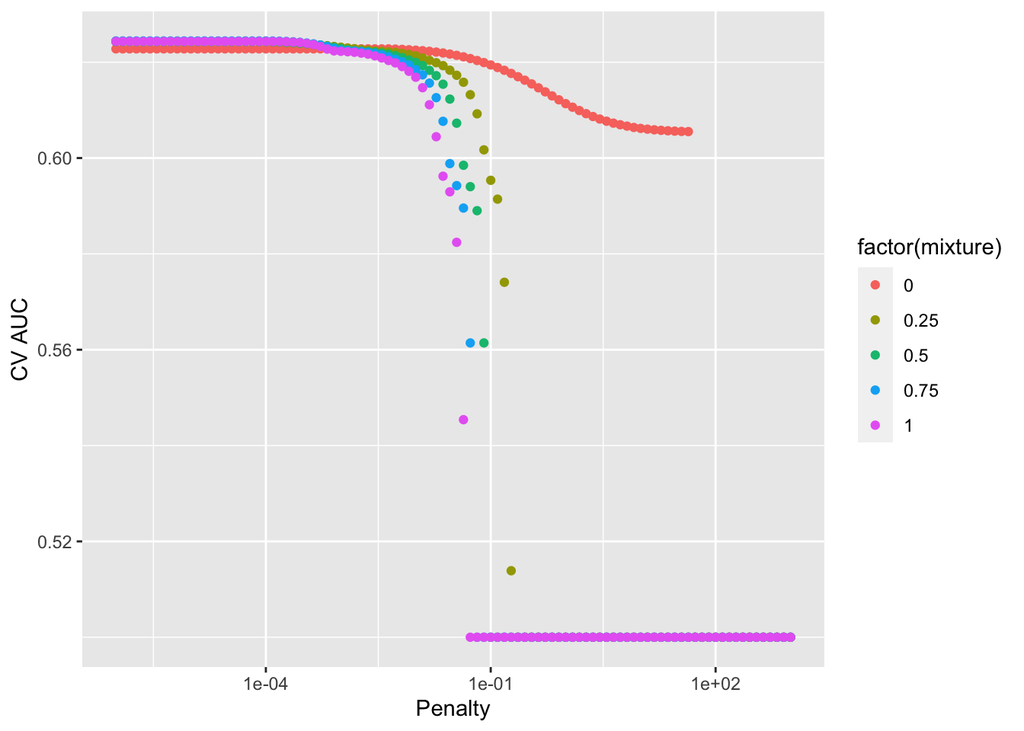

```r
logit_fit  %>%
  collect_metrics() %>%
  print(width = Inf) %>%
  filter(.metric == "roc_auc") %>%
  ggplot(mapping = aes(x = penalty, y = mean, color = factor(mixture))) +
  geom_point() +
  labs(x = "Penalty", y = "CV AUC") +
  scale_x_log10()
```

```r
best_logit <- logit_fit %>%
  select_best("roc_auc")
```

#### Random forest

```r
rf_fit <-
  tune_grid(
    object = rf_wf,
    resamples = folds,
    grid = rf_param_grid,
    control = control_stack_grid()
  )
```

```
ℹ The workflow being saved contains a recipe, which is 18.29 Mb in ℹ memory. If
this was not intentional, please set the control setting ℹ `save_workflow =
FALSE`.
```

```
# A tibble: 50 × 8
    mtry trees .metric  .estimator  mean     n std_err .config
   <int> <int> <chr>    <chr>      <dbl> <int>   <dbl> <chr>
 1     1   100 accuracy binary     0.591     5 0.00410 Preprocessor1_Model01
 2     1   100 roc_auc  binary     0.640     5 0.00255 Preprocessor1_Model01
 3     1   175 accuracy binary     0.593     5 0.00515 Preprocessor1_Model02
 4     1   175 roc_auc  binary     0.642     5 0.00276 Preprocessor1_Model02
 5     1   250 accuracy binary     0.594     5 0.00299 Preprocessor1_Model03
 6     1   250 roc_auc  binary     0.644     5 0.00246 Preprocessor1_Model03
 7     1   325 accuracy binary     0.595     5 0.00390 Preprocessor1_Model04
 8     1   325 roc_auc  binary     0.645     5 0.00295 Preprocessor1_Model04
 9     1   400 accuracy binary     0.596     5 0.00456 Preprocessor1_Model05
10     1   400 roc_auc  binary     0.646     5 0.00258 Preprocessor1_Model05
# ℹ 40 more rows
```

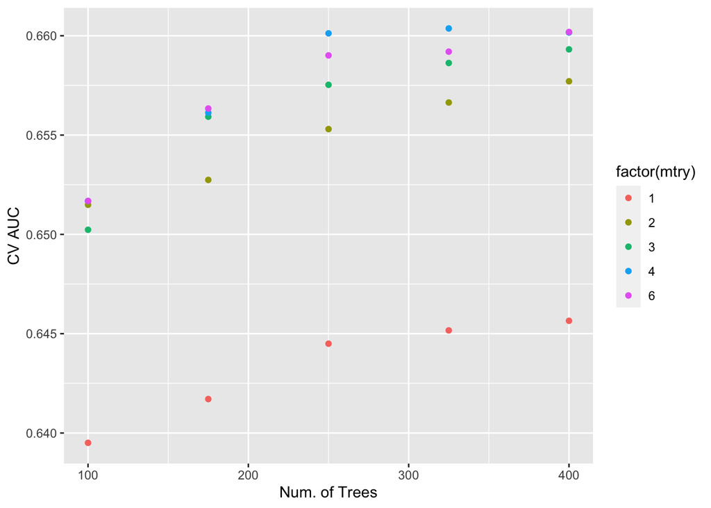

```r
rf_fit %>%
  collect_metrics() %>%
  print(width = Inf) %>%
  filter(.metric == "roc_auc") %>%
  ggplot(mapping = aes(x = trees, y = mean, color = factor(mtry))) +
  geom_point() +
  # geom_line() +
  labs(x = "Num. of Trees", y = "CV AUC")
```

```r
best_rf <- rf_fit %>%
  select_best("roc_auc")
```

#### MLP

```r
mlp_fit <- mlp_wf %>%
  tune_grid(
    resamples = folds,
    grid = mlp_param_grid,
    metrics = metric_set(roc_auc, accuracy)
  )
```

[output not shown]

[output cut: 35 more lines]

[output not shown]

```
# A tibble: 18 × 8
   hidden_units dropout .metric  .estimator  mean     n std_err
          <int>   <dbl> <chr>    <chr>      <dbl> <int>   <dbl>
 1            1     0   accuracy binary     0.520     5 0.00456
 2            1     0   roc_auc  binary     0.5       5 0
 3           10     0   accuracy binary     0.599     5 0.00127
 4           10     0   roc_auc  binary     0.635     5 0.00265
 5           20     0   accuracy binary     0.602     5 0.00170
 6           20     0   roc_auc  binary     0.637     5 0.00216
 7            1     0.3 accuracy binary     0.520     5 0.00456
 8            1     0.3 roc_auc  binary     0.5       5 0
 9           10     0.3 accuracy binary     0.598     5 0.00287
10           10     0.3 roc_auc  binary     0.633     5 0.00294
11           20     0.3 accuracy binary     0.601     5 0.00222
12           20     0.3 roc_auc  binary     0.634     5 0.00243
```

[output cut: 26 more lines]

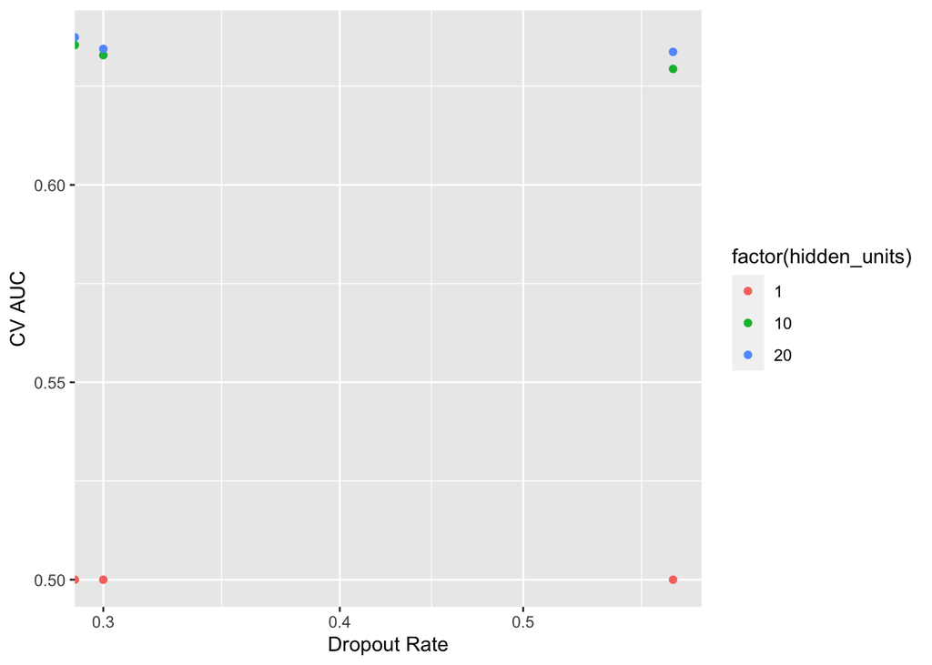

```r
mlp_fit %>%
  collect_metrics() %>%
  print(width = Inf) %>%
  filter(.metric == "roc_auc") %>%
  ggplot(mapping = aes(x = dropout, y = mean, color = factor(hidden_units))) +
  geom_point() +
  labs(x = "Dropout Rate", y = "CV AUC") +
  scale_x_log10()
```

```r
best_mlp <- mlp_fit %>%
  select_best("roc_auc")
```

#### Boosting

```r
gb_fit <-
  tune_grid(
    object = gb_wf,
    resamples = folds,
    grid = gb_param_grid,
    control = control_stack_grid()
  )
```

```
ℹ The workflow being saved contains a recipe, which is 18.29 Mb in ℹ memory. If
this was not intentional, please set the control setting ℹ `save_workflow =
FALSE`.
```

```
# A tibble: 60 × 8
   tree_depth learn_rate .metric  .estimator  mean     n std_err
        <int>      <dbl> <chr>    <chr>      <dbl> <int>   <dbl>
 1          1  0.00001   accuracy binary     0.550     5 0.00338
 2          1  0.00001   roc_auc  binary     0.539     5 0.00172
 3          3  0.00001   accuracy binary     0.569     5 0.00230
 4          3  0.00001   roc_auc  binary     0.575     5 0.00317
 5          6  0.00001   accuracy binary     0.583     5 0.00409
 6          6  0.00001   roc_auc  binary     0.610     5 0.00450
 7          1  0.0000599 accuracy binary     0.550     5 0.00338
 8          1  0.0000599 roc_auc  binary     0.539     5 0.00172
 9          3  0.0000599 accuracy binary     0.570     5 0.00269
10          3  0.0000599 roc_auc  binary     0.580     5 0.00402
   .config
   <chr>
 1 Preprocessor1_Model01
 2 Preprocessor1_Model01
 3 Preprocessor1_Model02
 4 Preprocessor1_Model02
 5 Preprocessor1_Model03
 6 Preprocessor1_Model03
 7 Preprocessor1_Model04
 8 Preprocessor1_Model04
 9 Preprocessor1_Model05
10 Preprocessor1_Model05
# ℹ 50 more rows
```

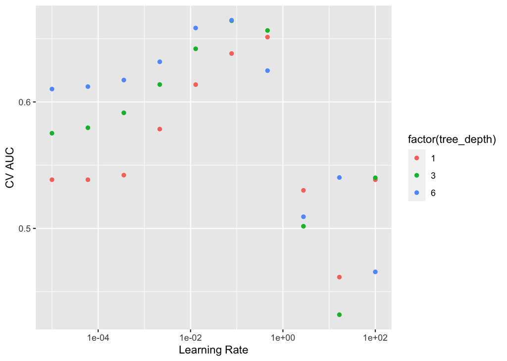

```r
gb_fit %>%
  collect_metrics() %>%
  print(width = Inf) %>%
  filter(.metric == "roc_auc") %>%
  ggplot(mapping = aes(x = learn_rate, y = mean, color = factor(tree_depth))) +
  geom_point() +
  labs(x = "Learning Rate", y = "CV AUC") +
  scale_x_log10()
```

```r
best_gb <- gb_fit %>%
  select_best("roc_auc")
```

#### Model Stacking

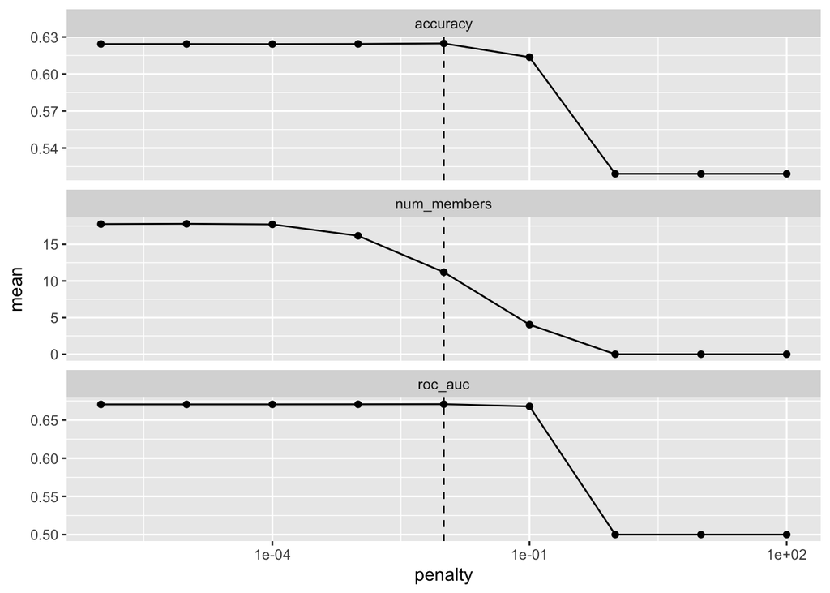

```r
mimic_model_st <-
  stacks() %>%
  #add_candidates(logit_fit) %>%
  add_candidates(rf_fit) %>%
  add_candidates(gb_fit) %>%
  blend_predictions(
    penalty = 10^(-6:2),
    metrics = c("roc_auc", "accuracy")
  ) %>%
  fit_members()
autoplot(mimic_model_st)
```

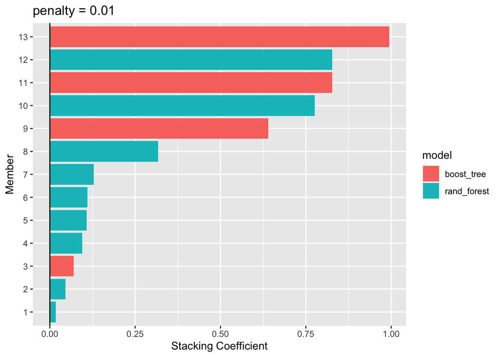

```r
autoplot(mimic_model_st, type = "weights")
```

### Finalize our model

```r
final_log_wf <- logit_wf %>%
  finalize_workflow(best_logit)

final_log_fit <-
  final_log_wf %>%
  last_fit(data_split)

final_rf_wf <- rf_wf %>%
  finalize_workflow(best_rf)

final_rf_fit <-
  final_rf_wf %>%
  last_fit(data_split)

final_mlp_wf <- mlp_wf %>%
  finalize_workflow(best_mlp)

final_mlp_fit <-
  final_mlp_wf %>%
  last_fit(data_split)
```

```
1144/1144 - 2s - 2s/epoch - 2ms/step
1144/1144 - 2s - 2s/epoch - 1ms/step
```

```r
final_gb_wf <- gb_wf %>%
  finalize_workflow(best_gb)

final_gb_fit <-
  final_gb_wf %>%
  last_fit(data_split)

mimic_pred <- Mimic_test %>%
  bind_cols(predict(mimic_model_st, ., type = "prob"))
```

#4. Compare model classification performance on the test set. Report both the area under ROC curve and accuracy for each machine learning algorithm and the model stacking. Interpret the results. What are the most important features in predicting long ICU stays? How do the models compare in terms of performance and interpretability?

#### logistic regression with enet regularization

```r
final_log_fit %>%
  collect_metrics()
```

```
# A tibble: 2 × 4
  .metric  .estimator .estimate .config
  <chr>    <chr>          <dbl> <chr>
1 accuracy binary         0.584 Preprocessor1_Model1
2 roc_auc  binary         0.615 Preprocessor1_Model1
```

#### Random forest

```r
final_rf_fit %>%
  collect_metrics()
```

```
# A tibble: 2 × 4
  .metric  .estimator .estimate .config
  <chr>    <chr>          <dbl> <chr>
1 accuracy binary         0.617 Preprocessor1_Model1
2 roc_auc  binary         0.660 Preprocessor1_Model1
```

#### MLP

```r
final_mlp_fit %>%
  collect_metrics()
```

```
# A tibble: 2 × 4
  .metric  .estimator .estimate .config
  <chr>    <chr>          <dbl> <chr>
1 accuracy binary         0.598 Preprocessor1_Model1
2 roc_auc  binary         0.630 Preprocessor1_Model1
```

#### Boosting

```r
final_gb_fit %>%
  collect_metrics()
```

```
# A tibble: 2 × 4
  .metric  .estimator .estimate .config
  <chr>    <chr>          <dbl> <chr>
1 accuracy binary         0.620 Preprocessor1_Model1
2 roc_auc  binary         0.665 Preprocessor1_Model1
```

#### Model Stacking

```r
yardstick::roc_auc(
  mimic_pred,
  truth = los_long,
  contains(".pred_False")
)
```

```
# A tibble: 1 × 3
  .metric .estimator .estimate
  <chr>   <chr>          <dbl>
1 roc_auc binary         0.670
```

### Model Performance Analysis

Let’s take a look at the feature importance of our models.

We can see form the logistic model that the most important feather is non invasive blood pressure systolic and follow with first_careunit. However, the logistic model didn’t perform well in the test set. So we can’t trust the feature importance from logistic model.

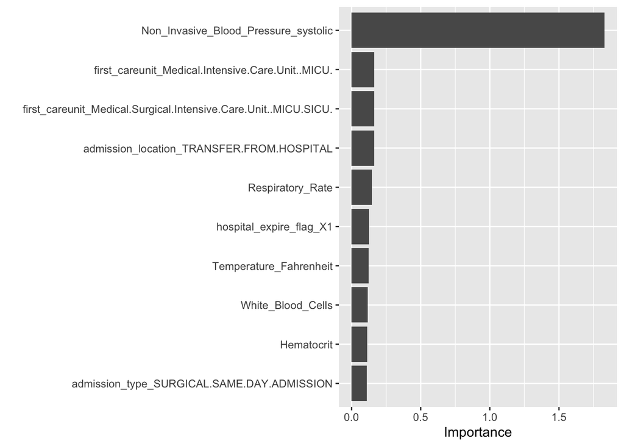

```r
final_log <- extract_workflow(final_log_fit)
final_log %>%
  extract_fit_parsnip() %>%
  vip()
```

The boosting tree model shows that the most important feather is temperature Fahrenheit and follow with non invasive blood pressure systolic which is also the most important feather in the logistic model. Other important feathers are mainly the the last lab measurements before the ICU stay, and first vital measurements during ICU stay

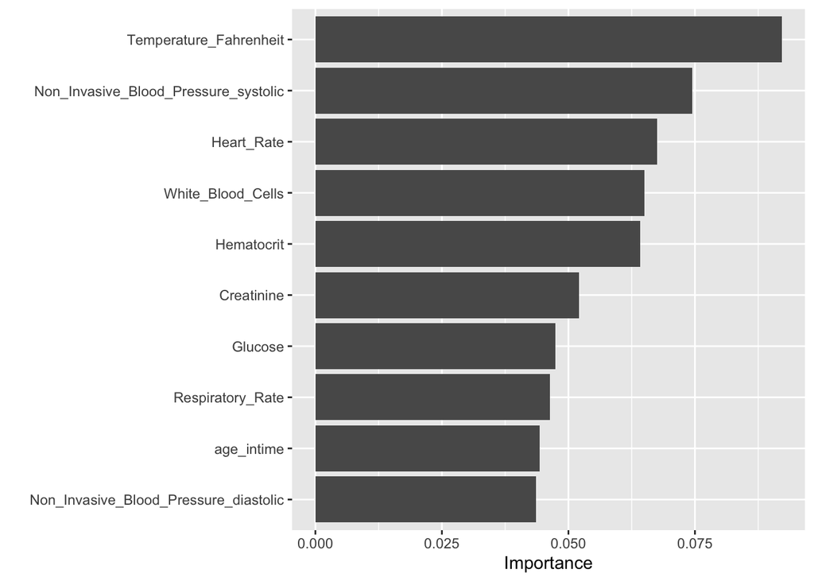

```r
final_tree <- extract_workflow(final_gb_fit)
final_tree %>%
  extract_fit_parsnip() %>%
  vip()
```

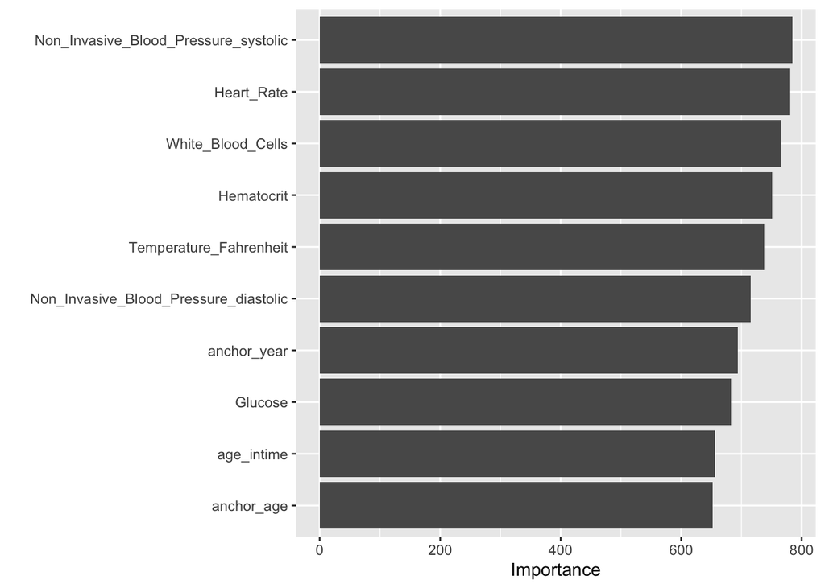

```r
final_rf <- extract_workflow(final_rf_fit)
final_rf %>%
  extract_fit_parsnip() %>%
  vip()
```

We have Logistic Regression with Elastic Net Regularization: Accuracy: 0.5837 ROC AUC: 0.6149

Boosting: Accuracy: 0.6197 ROC AUC: 0.6653

Model Stacking: ROC AUC: 0.6705

The model stacking approach has the highest ROC AUC, suggesting it may be the best at discriminating between the two classes. Gradient boosting follows closely in terms of ROC AUC and has the highest accuracy among the individual models.

The logistic regression model, while typically more interpretable due to its linear nature and direct coefficient significance, appears to be the least accurate in this case. The MLP shows an ROC AUC that is moderately good, but its accuracy is lower than that of the random forest and boosting models.

From the feature importance analysis, we can see all three models agree that non invasive blood pressure systolic is one of the most important features in predicting long ICU stays. The last lab measurements before the ICU stay and first vital measurements during ICU stay are also in top important features. This suggests that the last lab measurements before the ICU stay and first vital measurements during ICU stay are important indicators of the patient’s condition and may be useful in predicting long ICU stays.

In this case, the trade-off between performance and interpretability is clear. While the model stacking approach gives the best ROC AUC, it does so at the cost of interpretability. On the other hand, logistic regression offers ease of interpretation but doesn’t perform as well. The gradient boosting model presents a good balance, with relatively high performance metrics and a degree of interpretability through feature importance scores.